# Uncertainty-based control over the use of one-shot memory for value-based decisions

- Motivation
- Design
- Experiment One
- Experiment Two
- Experiment Three

# Motivation

1. Because decisions are often time sensitive and retrieving a single experience is more computationally expensive than referencing value extracted over many experiences (Lengyel & Dayan, 2008), it is unclear why the brain would develop the ability to resolve decisions using value encoded in one shot.
2. When prior experience is sparse, such as early in learning or in highly novel environments, artificial agents demonstrate augmented performance when outcomes from individual past choices are considered (Lengyel & Dayan, 2008; Blundell et al., 2016; Santoro et al., 2016)
3. Biologically inspiried artifical neural networks benefit from shifting decisions based on valued encoded in one-shot to value encoded incrementally ONLY when long-term value is easily estimated (Santoro et al., 2016). This suggests that utilizing incrementally constructed expected value to guide decisions may be a useful strategy only when an agent can be certain that it is possible to estimate such a quantity.
4. Sampling individual episodes should only be a worthwhile endeavor when it is either difficult to accurately estimate average value (noise) or there is a high amount of uncertainty around an estimate (risk/variance). **Thus, we expect there to be greater episodic control over decisions when incrementally constructed estimates are uncertain**

# Design

[figure not shown]

# Experiment One

**Prediction**: Participants should be more likely to avoid objects associated with a value less than the average value ($0.60), and choose objects associated with a value greater than the average value, when the circle’s average value comes from the unreliable compared to the reliable distribution.

```python
from datetime import datetime
import os, warnings, pickle
warnings.filterwarnings('ignore')
import numpy as np
import pandas as pd
import matplotlib.pyplot as plt
import seaborn as sns
from bambi import Model
import pymc3 as pm

sns.set_context("poster")
```

```python
import exp1_analysis as ea1
```

```python
test_data = pd.read_csv("data/study1/study1_testdata.csv")
old_data = test_data[test_data.old_trial == True]
old_data['old_value'] = old_data['old_value'].astype('float')
old_data = ea1.getRunningEstimates(old_data=old_data)
```

```python
old_data = old_data.loc[old_data.index[old_data['prop_response'] >= 0.9]]
print("N = %s"%len(old_data.subjectID.unique()))
```

```
N = 250
```

### Proportion of old object choice as a function of value and circle reliability

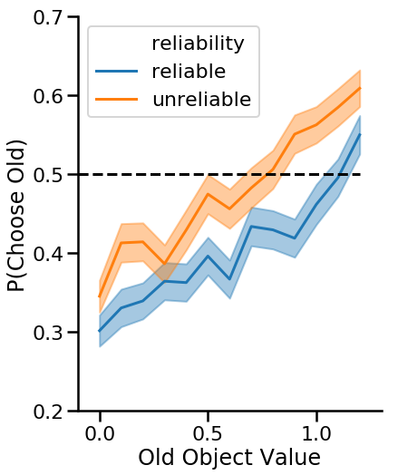

```python
# Visualize data using within-subject confidence intervals
old_data_adjusted = ea1.adjustChoiceProportions(old_data=old_data)

# Plot proportion of old choices with within-subject 95% confidence intervals
f, ax = ea1.plotProportionChoice(old_data=old_data,old_data_adjusted=old_data_adjusted)
plt.show()
```

### Objects are chosen more frequently when circle's value is unreliable

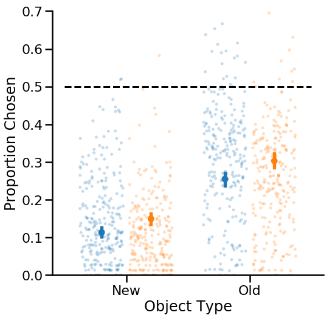

```python
test_choice_data = ea1.getOverallChoiceProportions(test_data=test_data)
object_choice_data = test_choice_data[test_choice_data.choice_type == "object"]
plt.figure(figsize=(8,8))
p = sns.pointplot(x="choice",y="prop_chosen",data=object_choice_data,scale=0.8,hue="reliability",
              join=False,dodge=0.4,hue_order=["reliable","unreliable"],order=["new","old"])
plt.setp(p.collections, edgecolor=None)
a = sns.stripplot(x="choice",y="prop_chosen",data=object_choice_data,zorder=0,hue="reliability",
                  dodge=True,jitter=0.35,order=["new","old"],alpha=0.25)
sns.despine(trim=False)
a.plot((-0.5,1.5),(0.5,0.5),'k--')
a.set_xticklabels(["New","Old"])
a.set_ylabel("Proportion Chosen")
a.set_xlabel("Object Type")
a.set_ylim([0,0.7])
a.legend_.remove()
plt.show()
```

### Mixed Effects Modeling

The following mixed effects logistic regression model was fit using Bayesian inference via MCMC sampling:

OldChosen ~ RiskAversion + EstMeanDiff + ClicksOutOfExperiment + OldValue *Reliability + (OldValue* Reliability | Subject)

- RiskAversion was computed as the difference between the proportion each participant chose new objects when the circle is unreliable and when the circle is reliable. Only new objects were included in this measure to separate the influence of risk aversion from memory for objects.
- EstimatedMeanDiff is the difference between the two circle’s running average value at the end of the training phase. This is to control for the possibility that participants experience the average value of each circle differently, which could underlie choice preferences.
- ClicksOutOfExperiment is the number of times each participant left the experiment window.

```python
pOld_model_file = open("models/study1/pOld_exp1_model.pkl",'rb')
pOld_model = pickle.load(pOld_model_file)
```

### There is a main effect of RiskAversion, OldValue, and Reliability

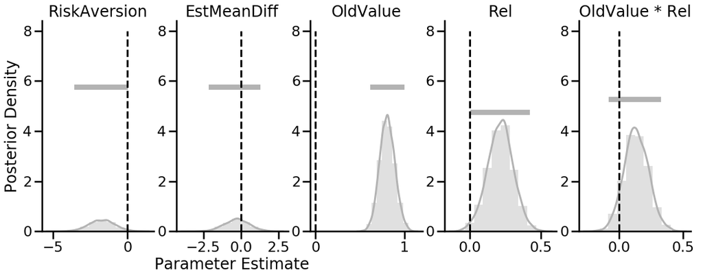

```python
ea1.plotPosteriors(trace=pOld_model["trace"],
                   n_samples=8000,
                   parameters=['new_preference','est_mean_diff','old_value','circle','old_value:circle'],
                   titles=["RiskAversion","EstMeanDiff","OldValue","Rel","OldValue * Rel"],
                   hdi_locs=[(5.75,5.75),(5.75,5.75),(5.75,5.75),(4.75,4.75),(5.25,5.25)])
```

### The Point of Equality (where the sigmoid crosses y=0.5) is different from 0.6 for circle=reliable but not circle=unreliable

```
HDP Unrel: [0.55945347 1.04809103] | M = 0.8037722523302513
HDP Rel: [0.91873371 1.50817049] | M = 1.2134521023197813
```

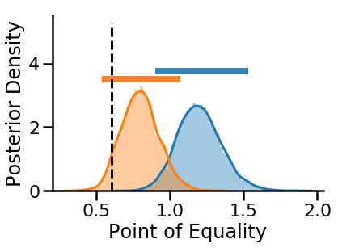

```python
rel_slopes = pOld_model["trace"]["old_value"]
unrel_slopes = pOld_model["trace"]["old_value"] + pOld_model["trace"]["old_value:circle"]
rel_intercepts = pOld_model["trace"]["Intercept"]
unrel_intercepts = pOld_model["trace"]["Intercept"] + pOld_model["trace"]["circle"]

rel_pse = (-1*(rel_intercepts))/rel_slopes
unrel_pse = (-1*(unrel_intercepts))/unrel_slopes

sns.distplot(rel_pse,bins=None)
f = sns.distplot(unrel_pse,bins=None);

f.set_xlabel("Point of Equality")
f.set_ylabel("Posterior Density")
sns.despine()

hpd_unrel = pm.stats.hpd(unrel_pse,alpha=0.05)
hpd_rel = pm.stats.hpd(rel_pse,alpha=0.05)

print("HDP Unrel: %s | M = %s"%(hpd_unrel[0], np.mean(hpd_unrel[0])))
print("HDP Rel: %s | M = %s"%(hpd_rel[0], np.mean(hpd_rel[0])))

plt.plot((hpd_unrel[0][0],hpd_unrel[0][1]),(3.5,3.5),linewidth=8,color="#fd8029")
plt.plot((hpd_rel[0][0],hpd_rel[0][1]),(3.75,3.75),linewidth=8,color="#3782b8")

plt.plot((0.6,0.6),(0,5.25),'k--');
```

# Experiment Two

- In experiment one, many individual objects are associated with values that are beyond the distribution of values that may be experienced when the circle option is reliable, leading to only a subset of cases (between 0.4 and 0.8) with greater competition between object values and the reliable circle.
- We reasoned that restricting the sampling of object values from this range of greater competition would allow us to measure the PoE with greater sensitivity. Thus, outcomes for each object in experiment two were randomly sampled from a uniform distribution with an average outcome of 0.60 but smaller range: Object ~ Uniform(0.40, 0.80)
- All other aspects of the experimental design were identical

```python
import exp2_analysis as ea2
```

```python
test_data = pd.read_csv("data/study3/study3_testdata.csv")
old_data = test_data[test_data.old_trial == True]
old_data['old_value'] = old_data['old_value'].astype('float')
old_data = ea2.getRunningEstimates(old_data=old_data)
```

```python
old_data = old_data.loc[old_data.index[old_data['prop_response'] >= 0.9]]
print("N = %s"%len(old_data.subjectID.unique()))
```

```
N = 103
```

### Proportion of old object choice as a function of value and circle reliability

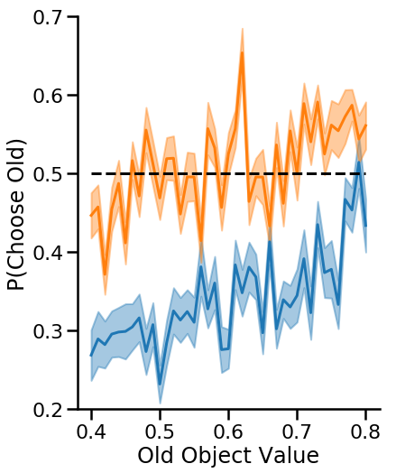

```python
# Visualize data using within-subject confidence intervals
old_data_adjusted = ea2.adjustChoiceProportions(old_data=old_data)

# Plot proportion of old choices with within-subject 95% confidence intervals
f, ax = ea2.plotProportionChoice(old_data_adjusted=old_data_adjusted)
plt.show()
```

### Like exp1, objects are chosen more frequently when circle's value is unreliable

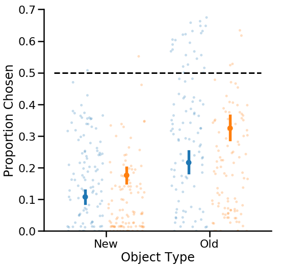

```python
test_choice_data = ea2.getOverallChoiceProportions(test_data=test_data)
object_choice_data = test_choice_data[test_choice_data.choice_type == "object"]
plt.figure(figsize=(8,8))
p = sns.pointplot(x="choice",y="prop_chosen",data=object_choice_data,scale=0.8,hue="reliability",
              join=False,dodge=0.4,hue_order=["reliable","unreliable"],order=["new","old"])
plt.setp(p.collections, edgecolor=None)
a = sns.stripplot(x="choice",y="prop_chosen",data=object_choice_data,zorder=0,hue="reliability",
                  dodge=True,jitter=0.35,order=["new","old"],alpha=0.25)
sns.despine(trim=False)
a.plot((-0.5,1.5),(0.5,0.5),'k--')
a.set_xticklabels(["New","Old"])
a.set_ylabel("Proportion Chosen")
a.set_xlabel("Object Type")
a.set_ylim([0,0.7])
a.legend_.remove()
plt.show()
```

### Mixed Effects Modeling

The same mixed effects logistic regression model was fit using Bayesian inference via MCMC sampling:

OldChosen ~ RiskAversion + EstMeanDiff + ClicksOutOfExperiment + OldValue *Reliability + (OldValue* Reliability | Subject)

```python
pOld_model_file = open("models/study3/pOld_exp3_model.pkl",'rb')
pOld_model = pickle.load(pOld_model_file)
```

### Like exp1, there is a main effect of RiskAversion, OldValue, and Reliability

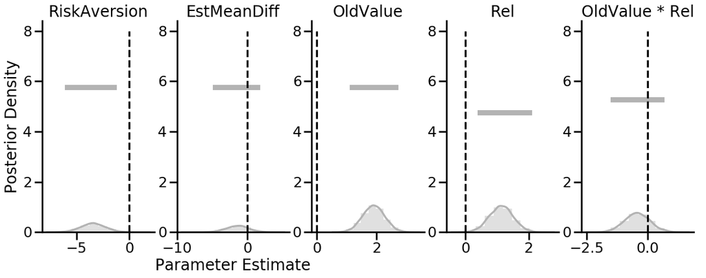

```python
ea2.plotPosteriors(trace=pOld_model["trace"],
                   n_samples=8000,
                   parameters=['new_preference','est_mean_diff','old_value','circle','old_value:circle'],
                   titles=["RiskAversion","EstMeanDiff","OldValue","Rel","OldValue * Rel"],
                   hdi_locs=[(5.75,5.75),(5.75,5.75),(5.75,5.75),(4.75,4.75),(5.25,5.25)])
```

### The Point of Equality is different from 0.6 for circle=reliable but not circle=unreliable

```
HDP Unrel: [0.02309    1.06820183] | M = 0.5456459137907294
HDP Rel: [0.75086667 1.35340003] | M = 1.0521333494320162
```

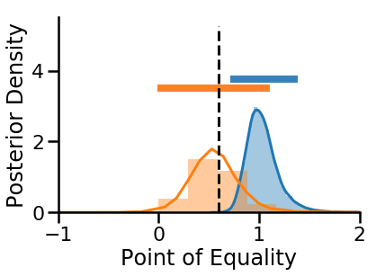

```python
rel_slopes = pOld_model["trace"]["old_value"]
unrel_slopes = pOld_model["trace"]["old_value"] + pOld_model["trace"]["old_value:circle"]
rel_intercepts = pOld_model["trace"]["Intercept"]
unrel_intercepts = pOld_model["trace"]["Intercept"] + pOld_model["trace"]["circle"]

rel_pse = (-1*(rel_intercepts))/rel_slopes
unrel_pse = (-1*(unrel_intercepts))/unrel_slopes

sns.distplot(rel_pse,bins=None)
f = sns.distplot(unrel_pse,bins=None);

f.set_xlabel("Point of Equality")
f.set_ylabel("Posterior Density")
sns.despine()

hpd_unrel = pm.stats.hpd(unrel_pse,alpha=0.05)
hpd_rel = pm.stats.hpd(rel_pse,alpha=0.05)

print("HDP Unrel: %s | M = %s"%(hpd_unrel[0], np.mean(hpd_unrel[0])))
print("HDP Rel: %s | M = %s"%(hpd_rel[0], np.mean(hpd_rel[0])))

plt.plot((hpd_unrel[0][0],hpd_unrel[0][1]),(3.5,3.5),linewidth=8,color="#fd8029")
plt.plot((hpd_rel[0][0],hpd_rel[0][1]),(3.75,3.75),linewidth=8,color="#3782b8")

f.axes.set_xlim([-1,2.0])

plt.plot((0.6,0.6),(0,5.25),'k--');
```

# Experiment Three

- In the previous experiments, participants were explicitly informed before beginning the task that one circle was more reliable than the other. While this instruction helped to aid participants in learning the relative certainties associated with each color of circle, real-world environments typically require such information to be inferred from experience. How might participants’ choice behavior change when they are no longer informed of differences between the circles ahead of time?
- To investigate this question, we removed all mentions to differences between the circle stimuli from the instructions. Additionally, in order to determine which participants inferred the reliability differences from experience, a post-task questionnaire asked whether participants thought one color of circle was more consistent than the other and, if so, to indicate which one.
- All other aspects of the experimental design were identical to experiment one.

```python
import exp3_analysis2 as ea3
```

```python
test_data = pd.read_csv("data/study2/study2_testdata.csv")
old_data = test_data[test_data.old_trial == True]
old_data['old_value'] = old_data['old_value'].astype('float')
old_data = ea3.getRunningEstimates(old_data=old_data)
```

```python
old_data = old_data.loc[old_data.index[old_data['prop_response'] >= 0.9]]
print("N = %s"%len(old_data.subjectID.unique()))
```

```
N = 194
```

```python
print(len(old_data[old_data.rel_identified == "Correct"].subjectID.unique())/194)
print(len(old_data[old_data.rel_identified == "No difference"].subjectID.unique())/194)
print(len(old_data[old_data.rel_identified == "Incorrect"].subjectID.unique())/194)
```

```
0.4948453608247423
0.29896907216494845
0.20618556701030927
```

### Proportion of old object choice as a function of value and circle reliability and PTQ answer

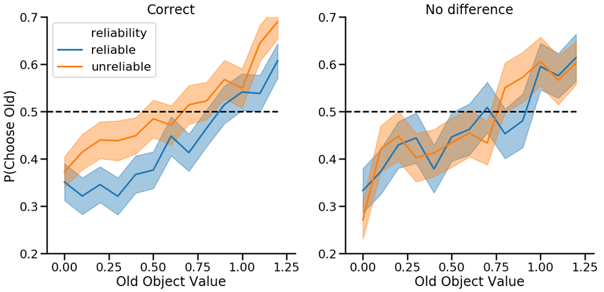

```python
f, axes = plt.subplots(1,2,figsize=(18,8))

# Plot proportion of old choices with within-subject 95% confidence intervals
ea3.plotProportionChoice(data_in=ea3.adjustChoiceProportions(old_data=old_data[old_data.rel_identified == "Correct"]),
                         ax=axes[0])

ea3.plotProportionChoice(data_in=ea3.adjustChoiceProportions(old_data=old_data[old_data.rel_identified == "No difference"]),
                         ax=axes[1])

axes[0].set_title("Correct")
axes[1].set_title("No difference")
axes[1].legend_.remove()
axes[1].set_ylabel("")

plt.show()
```

### Like exp1, objects are chosen more frequently when circle's value is unreliable and participants were aware of reliability differences

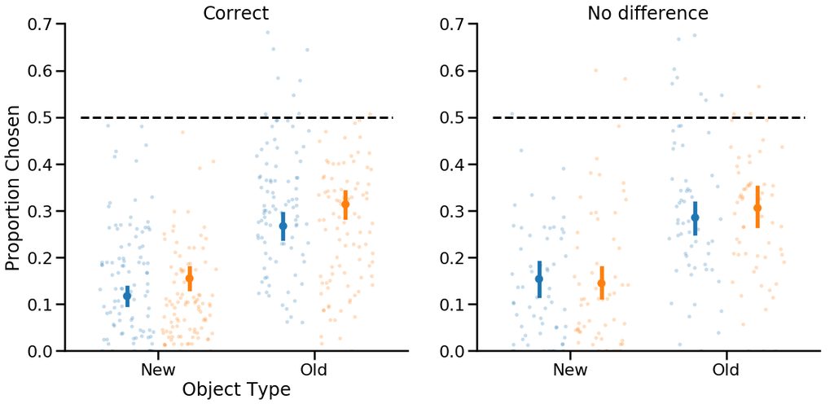

```python
f, axes = plt.subplots(1,2,figsize=(18,8))

for rel_id_i, rel_id in enumerate(["Correct","No difference"]):

    test_choice_data = ea3.getOverallChoiceProportions(test_data=test_data[test_data.rel_identified == rel_id])

    # Proportion choice for object trials only
    object_choice_data = test_choice_data[test_choice_data.choice_type == "object"]

    p = sns.pointplot(x="choice",y="prop_chosen",data=object_choice_data,scale=0.8,hue="reliability",
                  join=False,dodge=0.4,hue_order=["reliable","unreliable"],order=["new","old"],ax=axes[rel_id_i])
    plt.setp(p.collections, edgecolor=None)
    a = sns.stripplot(x="choice",y="prop_chosen",data=object_choice_data,zorder=0,hue="reliability",
                      dodge=True,jitter=0.35,order=["new","old"],alpha=0.25,ax=axes[rel_id_i])
    sns.despine(trim=False)
    a.plot((-0.5,1.5),(0.5,0.5),'k--')
    a.set_title(rel_id)
    a.set_xticklabels(["New","Old"])
    if rel_id_i == 0:
        a.set_ylabel("Proportion Chosen")
        a.set_xlabel("Object Type")
    else:
        a.set_ylabel("")
        a.set_xlabel("")
    a.set_ylim([0,0.7])
    a.legend_.remove()

plt.show()
```

### Mixed Effects Modeling

The same mixed effects logistic regression model was fit using Bayesian inference via MCMC sampling:

OldChosen ~ RiskAversion + EstMeanDiff + ClicksOutOfExperiment + OldValue *Reliability + (OldValue* Reliability | Subject)

```python
pOld_model_corr = pickle.load(open("models/study2/pOld_exp2corr_model.pkl",'rb'))
pOld_model_nodiff = pickle.load(open("models/study2/pOld_exp2nodiff_model.pkl",'rb'))
```

### Correct group shows a main effect of OldValue and Reliability

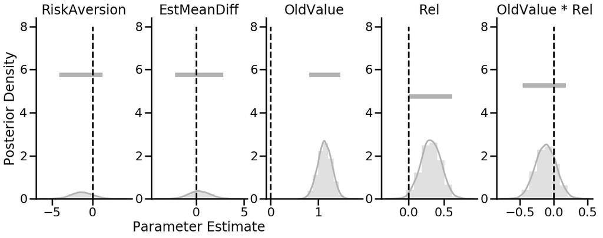

```python
ea3.plotPosteriors(trace=pOld_model_corr["trace"],
                   n_samples=8000,
                   parameters=['new_preference','est_mean_diff','old_value','circle','old_value:circle'],
                   titles=["RiskAversion","EstMeanDiff","OldValue","Rel","OldValue * Rel"],
                   hdi_locs=[(5.75,5.75),(5.75,5.75),(5.75,5.75),(4.75,4.75),(5.25,5.25)])
```

### Correct group Point of Equality looks similar to experiment one

```
HDP Unrel: [0.34625519 1.03501485] | M = 0.6906350166041415
HDP Rel: [0.6325039  1.19892169] | M = 0.9157127947761725
```

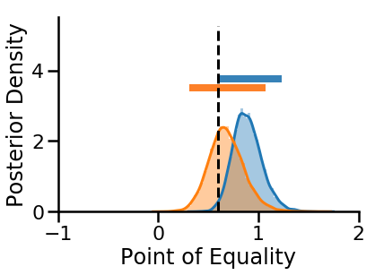

```python
rel_slopes = pOld_model_corr["trace"]["old_value"]
unrel_slopes = pOld_model_corr["trace"]["old_value"] + pOld_model_corr["trace"]["old_value:circle"]
rel_intercepts = pOld_model_corr["trace"]["Intercept"]
unrel_intercepts = pOld_model_corr["trace"]["Intercept"] + pOld_model_corr["trace"]["circle"]

rel_pse = (-1*(rel_intercepts))/rel_slopes
unrel_pse = (-1*(unrel_intercepts))/unrel_slopes

sns.distplot(rel_pse,bins=None)
f = sns.distplot(unrel_pse,bins=None);

f.set_xlabel("Point of Equality")
f.set_ylabel("Posterior Density")
sns.despine()

hpd_unrel = pm.stats.hpd(unrel_pse,alpha=0.05)
hpd_rel = pm.stats.hpd(rel_pse,alpha=0.05)

print("HDP Unrel: %s | M = %s"%(hpd_unrel[0], np.mean(hpd_unrel[0])))
print("HDP Rel: %s | M = %s"%(hpd_rel[0], np.mean(hpd_rel[0])))

plt.plot((hpd_unrel[0][0],hpd_unrel[0][1]),(3.5,3.5),linewidth=8,color="#fd8029")
plt.plot((hpd_rel[0][0],hpd_rel[0][1]),(3.75,3.75),linewidth=8,color="#3782b8")

f.axes.set_xlim([-1,2.0])

plt.plot((0.6,0.6),(0,5.25),'k--');
```

### No difference group shows a main effect of RiskAversion, a main effect of OldValue, and NO main effect of reliability

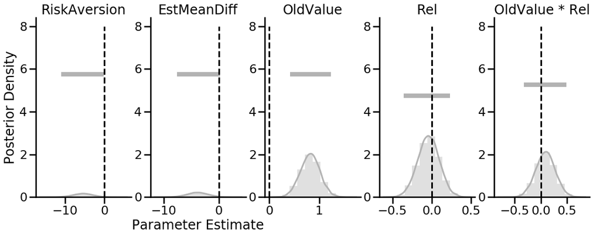

```python
ea3.plotPosteriors(trace=pOld_model_nodiff["trace"],
                   n_samples=8000,
                   parameters=['new_preference','est_mean_diff','old_value','circle','old_value:circle'],
                   titles=["RiskAversion","EstMeanDiff","OldValue","Rel","OldValue * Rel"],
                   hdi_locs=[(5.75,5.75),(5.75,5.75),(5.75,5.75),(4.75,4.75),(5.25,5.25)])
```

### The Point of Equality estimate contains 0.6 for both reliability stimulus conditions

```
HDP Unrel: [0.30911304 1.39629374] | M = 0.8527033904797686
HDP Rel: [0.32771958 1.56469789] | M = 0.9462087358515765
```

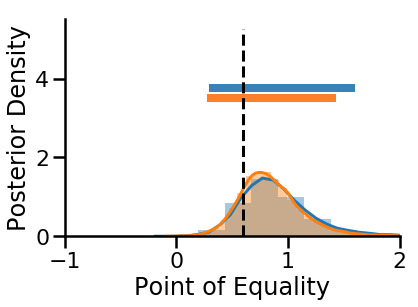

```python
rel_slopes = pOld_model_nodiff["trace"]["old_value"]
unrel_slopes = pOld_model_nodiff["trace"]["old_value"] + pOld_model_nodiff["trace"]["old_value:circle"]
rel_intercepts = pOld_model_nodiff["trace"]["Intercept"]
unrel_intercepts = pOld_model_nodiff["trace"]["Intercept"] + pOld_model_nodiff["trace"]["circle"]

rel_pse = (-1*(rel_intercepts))/rel_slopes
unrel_pse = (-1*(unrel_intercepts))/unrel_slopes

sns.distplot(rel_pse,bins=None)
f = sns.distplot(unrel_pse,bins=None);

f.set_xlabel("Point of Equality")
f.set_ylabel("Posterior Density")
sns.despine()

hpd_unrel = pm.stats.hpd(unrel_pse,alpha=0.05)
hpd_rel = pm.stats.hpd(rel_pse,alpha=0.05)

print("HDP Unrel: %s | M = %s"%(hpd_unrel[0], np.mean(hpd_unrel[0])))
print("HDP Rel: %s | M = %s"%(hpd_rel[0], np.mean(hpd_rel[0])))

plt.plot((hpd_unrel[0][0],hpd_unrel[0][1]),(3.5,3.5),linewidth=8,color="#fd8029")
plt.plot((hpd_rel[0][0],hpd_rel[0][1]),(3.75,3.75),linewidth=8,color="#3782b8")

f.axes.set_xlim([-1,2.0])

plt.plot((0.6,0.6),(0,5.25),'k--');
```

# Experiment Four (Ongoing)

- We are currently attempting replication of experiment one in person with eyetracking.
- If incremental uncertainty is used to determine whether one-shot memory should be engaged, then participants should first attend to the circle (regardless of color)